# Reporte de Polución para Usme y Bogotá

Periodo: 2024-08-31 a 2024-09-30

## Usme

#### Polución general

Para **Usme** la polución promedio del mes fue de 8.26 microgramos por metro cúbico, con 2 días arriba del límite recomendado. Esto lo coloca como la 14va localidad con más polución y como la 15va con más días arriba del límite recomendado. .

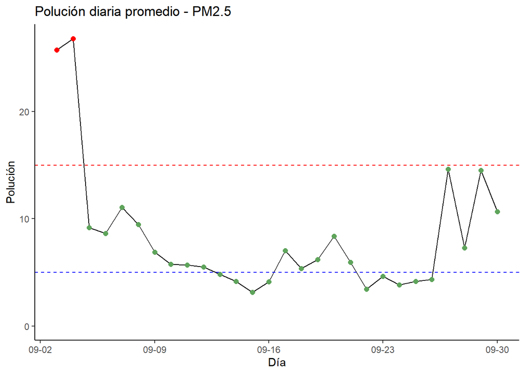

La localidad cuenta con 13 escuelas en el estudio. A continuación se muestra la polución para cada una de las escuelas de la localidad, indicando los días por arriba del límite recomendado.

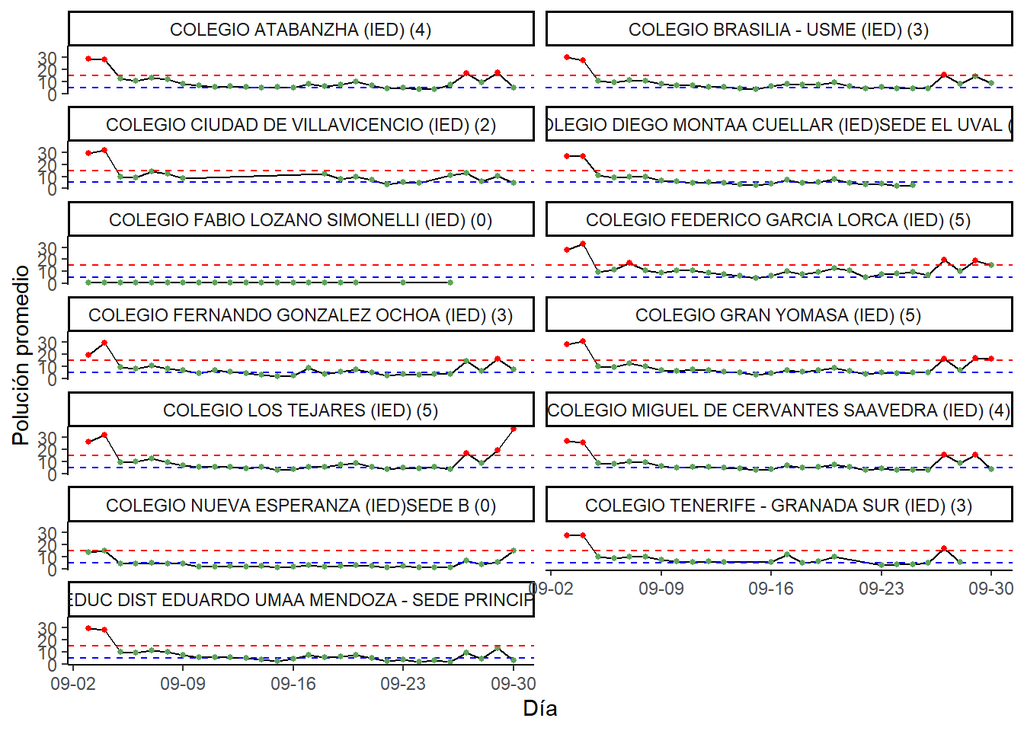

#### Polución por escuela

##### Polución mensual promedio

[interactive chart not shown]

| Escuela | PM2.5 | Dias arriba del límite |
| --- | --- | --- |
| COLEGIO ATABANZHA (IED) | 8.92 | 4 |
| COLEGIO BRASILIA - USME (IED) | 8.36 | 3 |
| COLEGIO CIUDAD DE VILLAVICENCIO (IED) | 10.65 | 2 |
| COLEGIO DIEGO MONTAA CUELLAR (IED)SEDE EL UVAL | 6.95 | 2 |
| COLEGIO FABIO LOZANO SIMONELLI (IED) | 0.70 | 0 |
| COLEGIO FEDERICO GARCIA LORCA (IED) | 11.02 | 5 |
| COLEGIO FERNANDO GONZALEZ OCHOA (IED) | 7.45 | 3 |
| COLEGIO GRAN YOMASA (IED) | 8.57 | 5 |
| COLEGIO LOS TEJARES (IED) | 8.47 | 5 |
| COLEGIO MIGUEL DE CERVANTES SAAVEDRA (IED) | 8.10 | 4 |
| COLEGIO NUEVA ESPERANZA (IED)SEDE B | 3.41 | 0 |
| COLEGIO TENERIFE - GRANADA SUR (IED) | 9.93 | 3 |
| INST EDUC DIST EDUARDO UMAA MENDOZA - SEDE PRINCIPAL | 7.57 | 2 |

##### Polución afuera y adentro

Las escuelas tienen monitores de polución adentro y afuera de los salones. A continuación presentamos la polución promedio diaria en ambos puntos (afuera y adentro) para cada escuela, e indicamos aquellas que tienen filtro de aire . Los huecos en la gráfica se deben a datos faltantes, que indican que alguno de los sensores no funcionó ese día.

**Escuelas con filtro**

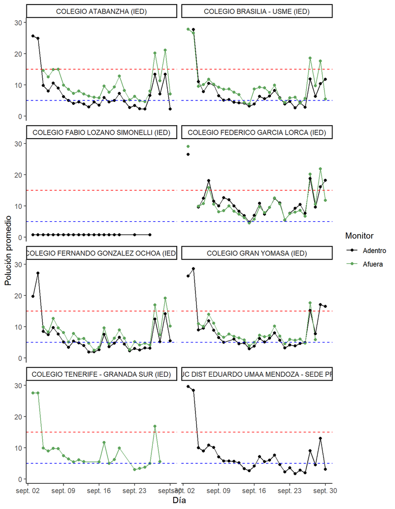

**Escuelas sin filtro**

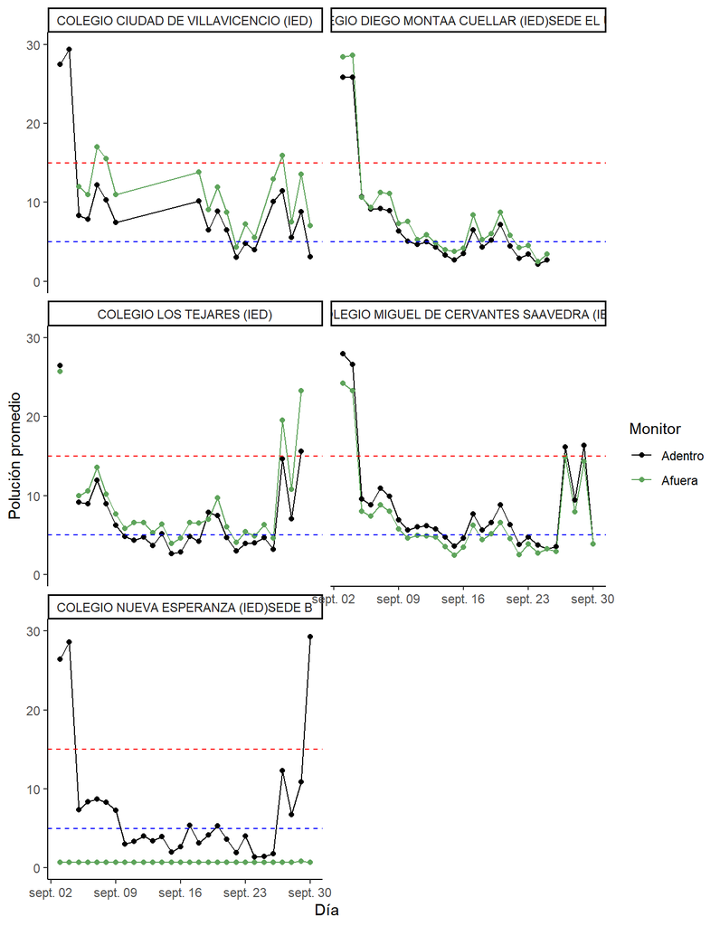

Adicionalmente, comparamos la polución promedio tanto adentro como afuera para las escuelas con filtros y sin filtros.

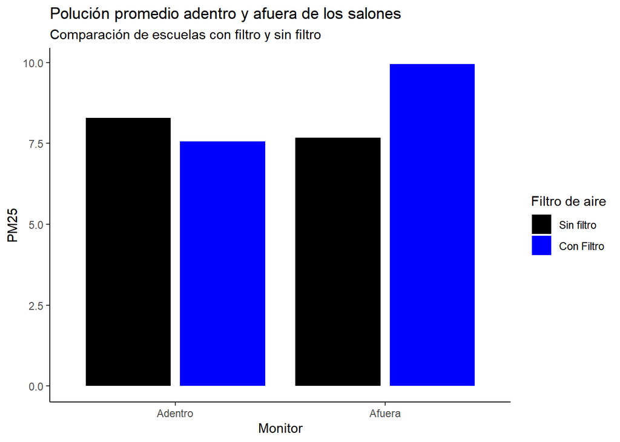

#### Uso de los filtros

Para aquellas escuelas de la localidad que tienen filtros de aire, es posible que en realidad no estén siendo utilizados. A continuación presentamos estas escuelas junto con la probabilidad de que estén utilizando sus filtros de aire, ordenadas de la menos probable a la más probable. Esto para ayudar a identificar y corregir aquellas escuelas que no están utilizando sus filtros.

| Escuela | Probabilidad de uso | Riesgo |
| --- | --- | --- |
| COLEGIO ATABANZHA (IED) | 1 | ✅ |
| COLEGIO BRASILIA - USME (IED) | 1 | ✅ |
| COLEGIO FEDERICO GARCIA LORCA (IED) | 1 | ✅ |
| COLEGIO FERNANDO GONZALEZ OCHOA (IED) | 1 | ✅ |
| COLEGIO GRAN YOMASA (IED) | 1 | ✅ |

#### Estado de los sensores

A continuación presentamos el diagnóstico de los monitores de polución, identificando lo siguiente:

- **Porcentaje de uso**: ¿Cuántas mediciones realizó sobre el total que debería realizar en los 31 días?
- **Número de días sin mediciones**: ¿Cuántos días el monitor no registró *ninguna* medida?
- **Status del sensor**: Presentamos la salud del sensor con base en el siguiente criterio
  - Ok: Registró al menos 85% de las lecturas, y no más de 5 días sin lecturas
  - En riesgo: Registró entre 50% y 85% de las lecturas, o 5-10 días sin lecturas
  - Fallando: Registró menos del 50% de las lecturas o más de 10 días sin lecturas

| Sede | Sensor | Está en el exterior | Porcentaje de lecturas | Dias sin registro | Status |
| --- | --- | --- | --- | --- | --- |
| COLEGIO BRASILIA - USME (IED) | a203 | No | 3.31 | 24 | 🔴 |
| COLEGIO FEDERICO GARCIA LORCA (IED) | smusic | No | 8.00 | 23 | 🔴 |
| COLEGIO TENERIFE - GRANADA SUR (IED) | ext | Sí | 43.27 | 6 | 🔴 |
| COLEGIO MIGUEL DE CERVANTES SAAVEDRA (IED) | s108 | No | 44.87 | 12 | 🔴 |
| COLEGIO CIUDAD DE VILLAVICENCIO (IED) | intel | No | 49.89 | 10 | 🔴 |
| COLEGIO CIUDAD DE VILLAVICENCIO (IED) | ext | Sí | 53.12 | 9 | 🔶 |
| COLEGIO CIUDAD DE VILLAVICENCIO (IED) | poliv | No | 53.12 | 9 | 🔶 |
| COLEGIO FERNANDO GONZALEZ OCHOA (IED) | ext | Sí | 56.85 | 1 | 🔶 |
| COLEGIO FABIO LOZANO SIMONELLI (IED) | bibli | No | 60.23 | 8 | 🔶 |
| INST EDUC DIST EDUARDO UMAA MENDOZA - SEDE PRINCIPAL | squimica | No | 64.51 | 7 | 🔶 |
| COLEGIO DIEGO MONTAA CUELLAR (IED)SEDE EL UVAL | s25 | No | 64.69 | 5 | 🔶 |
| COLEGIO FERNANDO GONZALEZ OCHOA (IED) | s205 | No | 65.44 | 0 | 🔶 |
| COLEGIO DIEGO MONTAA CUELLAR (IED)SEDE EL UVAL | aula1 | No | 77.90 | 5 | 🔶 |
| COLEGIO DIEGO MONTAA CUELLAR (IED)SEDE EL UVAL | ext | Sí | 77.90 | 5 | 🔶 |
| COLEGIO GRAN YOMASA (IED) | lbiol | No | 83.44 | 1 | 🔶 |
| COLEGIO GRAN YOMASA (IED) | ext | Sí | 88.36 | 2 | ✅ |
| COLEGIO BRASILIA - USME (IED) | a125 | No | 90.33 | 0 | ✅ |
| COLEGIO FEDERICO GARCIA LORCA (IED) | ext | Sí | 91.18 | 0 | ✅ |
| COLEGIO FEDERICO GARCIA LORCA (IED) | sdanza | No | 91.63 | 0 | ✅ |
| COLEGIO MIGUEL DE CERVANTES SAAVEDRA (IED) | ext | Sí | 91.85 | 0 | ✅ |
| COLEGIO ATABANZHA (IED) | ext | Sí | 92.26 | 0 | ✅ |
| COLEGIO LOS TEJARES (IED) | ext | Sí | 92.45 | 0 | ✅ |
| COLEGIO ATABANZHA (IED) | sa101 | No | 92.56 | 0 | ✅ |
| COLEGIO LOS TEJARES (IED) | 11 | No | 92.71 | 0 | ✅ |
| COLEGIO BRASILIA - USME (IED) | ext | Sí | 92.86 | 0 | ✅ |
| COLEGIO MIGUEL DE CERVANTES SAAVEDRA (IED) | s107 | No | 92.86 | 0 | ✅ |
| COLEGIO NUEVA ESPERANZA (IED)SEDE B | ext | Sí | 92.89 | 0 | ✅ |
| INST EDUC DIST EDUARDO UMAA MENDOZA - SEDE PRINCIPAL | sciencia | No | 92.97 | 0 | ✅ |
| COLEGIO NUEVA ESPERANZA (IED)SEDE B | slabor | No | 92.97 | 0 | ✅ |

## Bogotá

#### Polución mensual promedio

[interactive chart not shown]

| Localidad | PM2.5 |
| --- | --- |
| ANTONIO NARIÑO | 8.97 |
| BARRIOS UNIDOS | 8.14 |
| BOSA | 12.60 |
| CIUDAD BOLIVAR | 15.40 |
| ENGATIVA | 10.53 |
| FONTIBON | 12.31 |
| KENNEDY | 15.31 |
| MARTIRES | 10.20 |
| PUENTE ARANDA | 12.82 |
| RAFAEL URIBE URIBE | 9.56 |
| SAN CRISTOBAL | 9.12 |
| SANTA FE | 8.97 |
| SUBA | 12.37 |
| TUNJUELITO | 10.05 |
| USAQUEN | 8.16 |
| USME | 8.26 |

#### Días arriba del límite recomendado

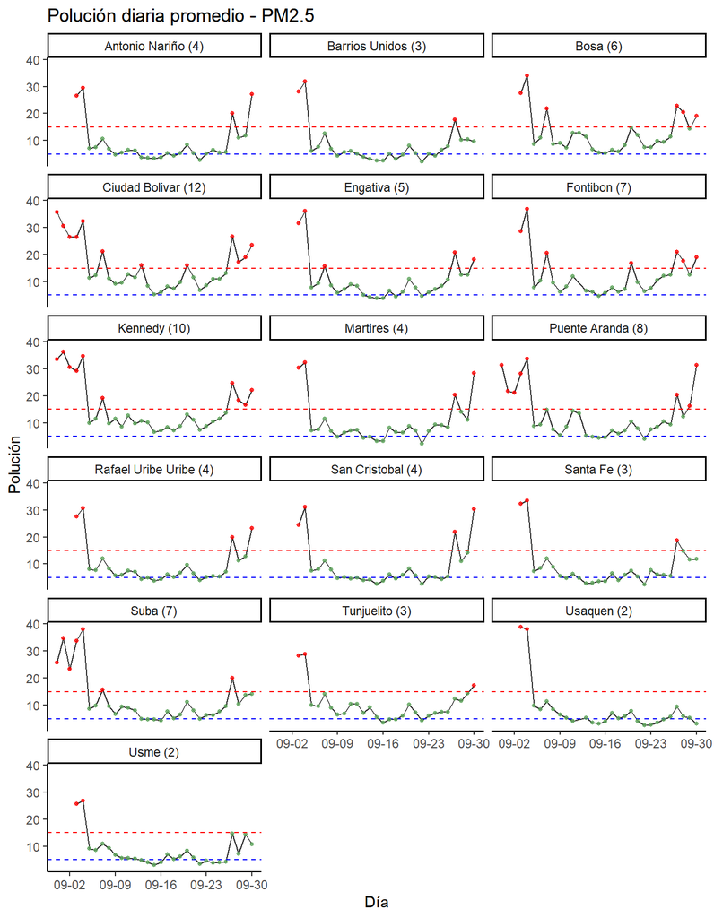